# R Beginners Course

Automating downloading

# Objective and contents

## Objective and contents

**Objective**: to automate the downloading of data in R as well as provide more information about some functions.

- Web crawling with R
- Iterative functions
- Downloading Products trough ftps
- Downloading Products trough https
- Working with NCDF files

# Web crawling with R

## Web crawling with R

Web crawling is a method of finding web links originating from one URL or a list of URLs. In this sense, we will need to retrieve URLs to download specific datasets.

# Iterative functions

## The apply Function

The apply function enables us to perform quick operations on a matrix, vector or array.

- Computational time using this function (as well as all others from the “apply” family) is faster than when using loops.

The apply function works as follows:

```r
apply(x, MARGIN, FUN)
```

## The apply Function

```r
apply(x, MARGIN, FUN)
```

**x** is an array, including a matrix

**MARGIN** is a vector giving the subscripts over which the function will be applied. Note that for a matrix, 1 indicates rows and 2 indicates columns

**FUN** is the function to be applied

## The apply Function

Let’s create small matrix to demonstrate how apply can be used.

```r
x <- matrix(1:16, nrow = 4)
print(x)
##      [,1] [,2] [,3] [,4]
## [1,]    1    5    9   13
## [2,]    2    6   10   14
## [3,]    3    7   11   15
## [4,]    4    8   12   16
apply(x, 1, mean)
## [1]  7  8  9 10
apply(x, 2, mean)
## [1]  2.5  6.5 10.5 14.5
```

## The apply Function

```
apply(x, 1, mean)                    vs                    apply(x, 2, mean)
```

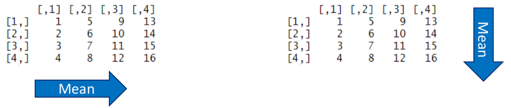

## The lapply Function

In the lapply function, a function is applied to each element of the list. The output is a list which therefore has the same length as the object.

This function works as follows:

```r
lapply(X, FUN)
```

**X** a vector or an object

**FUN** the function to be applied

## The lapply Function

Let’s create an object with plans for next winter to demonstrate the use of lapply.

```r
winter.plans <- c("Mountains", "Skiing", "Christmas Market", "Holiday")
# The output is a list of 4 elements (one for each string)
lapply(winter.plans, nchar)
## [[1]]
## [1] 9
##
## [[2]]
## [1] 6
##
## [[3]]
## [1] 16
##
## [[4]]
## [1] 7
```

The function *nchar* returns the number of characters in a string.

## The lapply Function

We can also use lapply on a list.

```r
number.list <-list(first = c(2, 4, 6), second = 10, third = c(40, 60, 80, 100))
lapply(number.list, sum)
## $first
## [1] 12
##
## $second
## [1] 10
##
## $third
## [1] 280
lapply(number.list, cumsum)
## $first
## [1]  2  6 12
##
## $second
## [1] 10
##
## $third
## [1]  40 100 180 280
```

## The lapply Function

Now, we’ll see a more tangible use of *lapply*. We will again use the *rbind*` function to combine population tables, but this time, for all files in a folder.

```r
data_path    <- "C:/Users/L6_Automating_Downloading_Data/Cities"
cities_files <- list.files(data_path, full.names = TRUE)
cities       <- lapply(cities_files, read.csv, header = TRUE)
```

```r
summary(cities)
##      Length Class      Mode
## [1,] 2      data.frame list
## [2,] 2      data.frame list
## [3,] 2      data.frame list
```

## The lapply Function

To create the combined table using the *rbind* function, we will also make use of the *do.call* function.

```r
combined_table <- do.call(rbind, cities)
class(combined_table)
## [1] "data.frame"
dim(combined_table)
## [1] 251   2
head(combined_table)
##             Name Population
## 1     Banja Luka    135,059
## 2          Biha?     39,690
## 3      Bijeljina     41,121
## 4 Bosanska Krupa     10,196
## 5          Br?ko     39,893
## 6        Bugojno     15,555
```

## The mapply function

The *mapply* function is a multivariate version of *sapply*. It applies a function to all the elements sequentially. - This gives us a way to call a non-vectorised function in a vectorised way-

This function works as follows:

```r
mapply(FUN, ..., MoreArgs)
```

**FUN** the function to be applied **…** multiple input arguments for mapply **MoreArgs** other arguments that are needed for the function

## The mapply function

Here is an example to explain the use of mapply:

```r
# The function rep repeats an object n times. In
#  this case we are applying this function to a
#  vector (11:4) while n takes values from 3 to 6.
mapply(rep, 11:14, 3:6)
## [[1]]
## [1] 11 11 11
##
## [[2]]
## [1] 12 12 12 12
##
## [[3]]
## [1] 13 13 13 13 13
##
## [[4]]
## [1] 14 14 14 14 14 14
```

## The mapply function

If the length of the arguments are different, they will be “recycled”.

```r
mapply(rep, 11:14, 3:4)
## [[1]]
## [1] 11 11 11
##
## [[2]]
## [1] 12 12 12 12
##
## [[3]]
## [1] 13 13 13
##
## [[4]]
## [1] 14 14 14 14
```

## The mapply function

Now, we will go back to the previous example, and use the mapply function to add the information about each country to the combined data table. First, we want the information about the country names and the number of entries for each country.

```r
library(tools)
country_names <- basename(file_path_sans_ext(cities_files))
```

```r
no_entries <- unlist(lapply(cities, nrow))
print(country_names)
## [1] "Bosnia_and_Herzegovina" "Hungary"                "Sweden"
print(no_entries)
## [1]  32  91 128
```

## The mapply function

```r
combined_table$Country <- unlist(mapply(rep, country_names, no_entries))
print(head(combined_table))
##             Name Population                Country
## 1     Banja Luka    135,059 Bosnia_and_Herzegovina
## 2          Biha?     39,690 Bosnia_and_Herzegovina
## 3      Bijeljina     41,121 Bosnia_and_Herzegovina
## 4 Bosanska Krupa     10,196 Bosnia_and_Herzegovina
## 5          Br?ko     39,893 Bosnia_and_Herzegovina
## 6        Bugojno     15,555 Bosnia_and_Herzegovina
print(tail(combined_table))
##               Name Population Country
## 246 V\xe4ster\xe5s     155551  Sweden
## 247   V\xe4stervik      36655  Sweden
## 248    V\xe4xj\xf6      94859  Sweden
## 249       Vellinge      36915  Sweden
## 250       Vetlanda      27502  Sweden
## 251          Ystad      30970  Sweden
```

## Advantages of using the apply family of functions

There are some advantages of using the apply family of functions compared to using for loops:

- They can make your code easier to read.
- They can make it easier to parallelise your code (i.e., designate processes to different cores of your computer).
- The code runs faster than for loops.

Note that there ways to parallelise your code using for loops. If you are interested in this, refer to the **doParallel** package.

# Downloading Products trough ftps

## File Transfer Protocol

An FTP server offers access to a directory, with sub-directories. The FTP protocol is used to store, organise and share large amounts of data and therefore is used by many data providers to store and share their products.

[figure not shown]

## Downloading CDC Data in R

**Step 1:** We want to use the packages **RCurl** and **R.utils**.

```r
install.packages("RCurl")
install.packages("R.utils")

library(RCurl)
library(R.utils)
```

The **RCurl** package provides functions to allow compose HTTP and FTP requests,while the **R.utils** package provides numerous useful functions. For this example, we need the package to download and unzip the files.

## Downloading CDC Data in R

**Step 2:** Define the ftp path:

```r
ftp <- "ftp://opendata.dwd.de/climate_environment/CDC/grids_germany/hourly/Project_TRY/wind_speed/"
```

**Step 3:** Create a folder where you will store the files and save its path in the output.path object.

```r
output.path <- "C:/Users/Documents/Wind/Raw"
```